# Sampling Distribution (30 pts)

MATH 240 | Lab #3

Author

In this lab, you will construct a *sampling distribution* of a statistic. Recall from class that the **sampling distribution of a statistic** is the distribution of the statistic calculated from many samples. It allows us to quantify and understand the sampling variability (and more generally, the distribution) of a statistic. The sampling distribution of a statistic is necessary for making both types of inference (hypothesis tests and confidence intervals). In practice, we usually work with a *model* for the sampling distribution. But in this lab, we have the luxury of creating the population *and* having access to resources (i.e. computing power) to take *many* samples from this population, thereby constructing the actual sampling distribution.

**Setting a seed:** We will take some random samples and build sampling distributions in this lab, which means we should set a seed at the start of your lab. This ensures reproducibility of your results, i.e. that you get the same results every time you run the code.

```r
set.seed(1234)
```

## Getting Started

### Load packages

In this lab, we will explore and visualize the data using the **tidyverse** suite of packages and the **openintro** package. We will also use the **infer** package for resampling.

Let’s load the packages. Again, if you’re using the RStudio server, you may not be able to load the **tidyverse** suite, and instead should load the specific packages: **dplyr** and **ggplot2** as you’ve done in previous labs. Modify the code below accordingly.

```r
library(tidyverse)
library(openintro)
library(infer)
```

### The data

A 2019 Gallup report states the following:

> The premise that scientific progress benefits people has been embodied in discoveries throughout the ages – from the development of vaccinations to the explosion of technology in the past few decades, resulting in billions of supercomputers now resting in the hands and pockets of people worldwide. Still, not everyone around the world feels science benefits them personally.

> **Source:** [World Science Day: Is Knowledge Power?](https://news.gallup.com/opinion/gallup/268121/world-science-day-knowledge-power.aspx)

The Wellcome Global Monitor finds that 20% of people globally do not believe that the work scientists do benefits people like them. In this lab, you will assume this 20% is a true population proportion and learn about how sample proportions can vary from sample to sample by taking smaller samples from the population. We will first create our population assuming a population size of 100,000. This means 20,000 (20%) of the population think the work scientists do does not benefit them personally and the remaining 80,000 think it does.

In the code below, we name our data frame `global_monitor` and the variable that contains responses to the question *“Do you believe that the work scientists do benefit people like you?”* `scientist_work`:

```r
global_monitor <- tibble(
  scientist_work = c(rep("Benefits", 80000), rep("Doesn't benefit", 20000))
)
```

We can visualize the distribution of these responses using a bar plot.

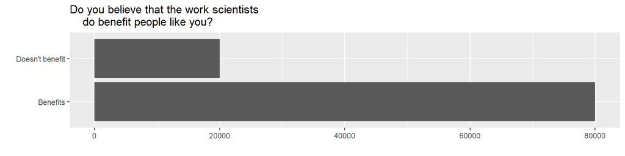

```r
global_monitor %>% ggplot(aes(x = scientist_work)) +
  geom_bar() +
  labs(
    x = "", y = "",
    title = "Do you believe that the work scientists
    do benefit people like you?"
  ) +
  coord_flip()
```

We can also obtain summary statistics to confirm we constructed the data frame correctly.

```r
global_monitor %>%
  count(scientist_work) %>%
  mutate(p = n /sum(n))
```

```
# A tibble: 2 × 3
  scientist_work      n     p
  <chr>           <int> <dbl>
1 Benefits        80000   0.8
2 Doesn't benefit 20000   0.2
```

## Sampling variability

In this lab, you have access to the entire population, but this is rarely the case in real life. Gathering information on an entire population is often extremely costly or impossible. Because of this, we often take a sample of the population and use that to understand the properties of the population.

If you are interested in estimating the proportion of people who don’t think the work scientists do benefits them, you can use the `sample_n` command to take a sample of size $n$ people from the population.

```r
samp1 <- global_monitor %>%
  sample_n(50)
```

This command takes a simple random sample of size 50 from the `global_monitor` dataset, and assigns the result to `samp1`. This is similar to randomly drawing names from a hat that contains the names of all in the population. Working with these 50 names is considerably simpler than working with all 100,000 people in the population.

1. Describe the distribution of responses in this sample. How does it compare to the distribution of responses in the population? **Hint:** Although the `sample_n` function takes a random sample of observations (i.e. rows) from the dataset, you can still refer to the variables in the dataset with the same names. Code you presented earlier for visualizing and summarising the population data will still be useful for the sample, however be careful to not label your proportion `p` since you’re now calculating a sample statistic, not a population parameter. You can customize the label of the statistics to indicate that it comes from the sample.

If you’re interested in estimating the proportion of all people who do not believe that the work scientists do benefits them, but you do not have access to the population data, your best single guess is the sample proportion.

Depending on which 50 people you selected, your estimate could be a bit above or a bit below the true population proportion of 20%. In general, though, the sample proportion turns out to be a pretty good estimate of the true population proportion, and you were able to get it by sampling less than 1% of the population.

2. Would you expect the sample proportion to match the sample proportion of another student’s sample? Why, or why not? If the answer is no, would you expect the proportions to be somewhat different or very different?
3. Take a second sample, also of size 50, and call it `samp2`. How does the sample proportion of `samp2` compare with that of `samp1`? Suppose we took two more samples, one of size 100 and one of size 1000. Which would you think would provide a more accurate estimate of the population proportion?

Not surprisingly, every time you take another random sample, you might get a different sample proportion. It’s useful to get a sense of just how much variability you should expect when estimating the population proportion this way.

## Constructing a sampling distribution

The distribution of sample proportions, called the *sampling distribution (of the proportion)*, can help you understand this (sampling) variability. In this section, you’’ll construct the sampling distribution of the proportion of adults who do not believe the work of scientists benefits people like them, based on samples of size $n=50$ adults.

In this lab, because you have access to the population and computing power, you can construct the sampling distribution for the sample proportion by actually taking samples from the population and repeating that many times. In the code below, we ask R to take 15,000 different samples of size 50 from the population, calculate the proportion of responses in each sample, filter for only the *Doesn’t benefit* responses, and store each result in a vector called `sample_props50`. The 15,000 different samples are known as *replicates*. The filter step is so that we only keep the proportion who don’t think science benefits (we don’t need to keep the proportion who *do* think science benefits). We specify `replace = TRUE` since we want each person in the population to have a 20% chance of not believing the work of scientists benefits them.

```r
sample_props50 <- global_monitor %>%
                    rep_sample_n(size = 50, reps = 15000, replace = TRUE) %>%
                    count(scientist_work) %>%
                    mutate(p_hat = n /sum(n)) %>%
                    filter(scientist_work == "Doesn't benefit")
```

And we can visualize the (sampling) distribution of these proportions with a histogram:

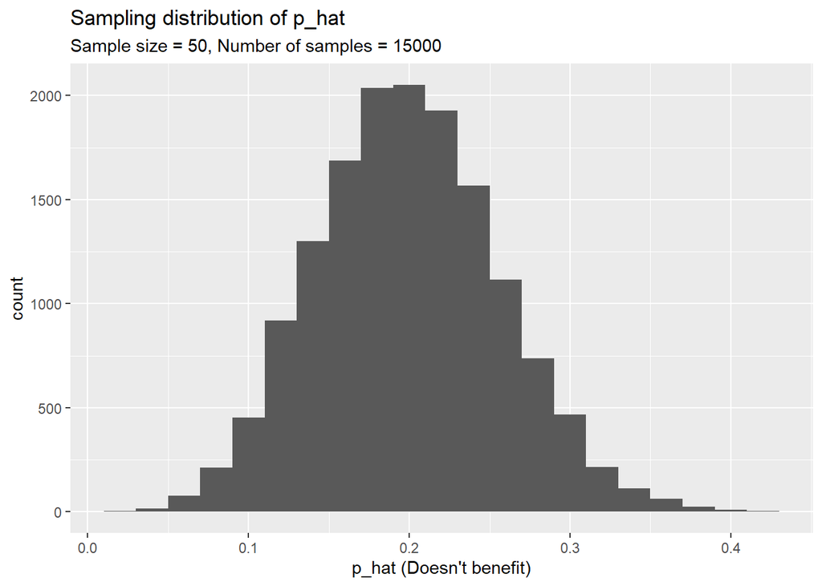

```r
ggplot(data = sample_props50, aes(x = p_hat)) +
  geom_histogram(binwidth = 0.02) +
  labs(
    x = "p_hat (Doesn't benefit)",
    title = "Sampling distribution of p_hat",
    subtitle = "Sample size = 50, Number of samples = 15000"
  )
```

1. How many rows are there in `sample_props50`? What does each row represent? Describe the shape, center, and spread of this sampling distribution. Include the histogram of your distribution.

Note that in practice one rarely gets to build true sampling distribution, because one rarely has access to the entire population. Without the `rep_sample_n` function, this would be painful. We would have to manually run the sampling 15,000 times! Note that for each of the 15,000 times we computed a proportion, we did so from a *different* sample.

## Effect of Sample Size on the Shape, Center, and Spread of a Sampling Distribution

1. What would happen to the sampling distribution if we took a *smaller* or *larger* sample? In this section, we explore the effect of *sample size* on the shape, center, and spread of the sampling distribution of proportions of *Doesn’t benefit*. So far, you’ve constructed a sampling distribution of proportions based on samples of size *50 adults*, using 15,000 replicates. Here you will construct sampling distributions of proportions based on samples of size $n=10$ and $n=100$ adults, still using 15,000 replicates. Review and understand your code from above where you constructed a sampling distribution of proportions based on $n=50$ adults, then modify it to construct sampling distributions based on samples of size $n=10$ and $n=100$ adults. Make a histogram of each of your sampling distributions.
2. For the two new sampling distributions you constructed (sample sizes 10 and 100), answer the following questions: What does each observation in the sampling distribution represent? Describe the center (mean), spread (standard deviation, aka ``standard error’’), and shape (symmetric/skewed) of the sampling distribution. How do these change as the sample size increases from 10 to 50 to 100?
3. Consider the sampling distribution where the sample size is 50. What do you think would happen to the shape and spread of the sampling distribution as you vary the number of replicates (aka Number of Samples) from 10 to infinity?

It turns out the sample proportion is what we call *unbiased*; this means that the *center* of the sampling distribution is at the true population proportion. Further, the spread of the distribution indicates how much variability is incurred by sampling only 50 people at a time from the population.

*This work is licensed under a Creative Commons Attribution-ShareAlike 4.0 International License.*